# Algorithm Class 44 - Design 6

System Design 2: Web Applications

July/24/2019

# 1 Web Application典型架構

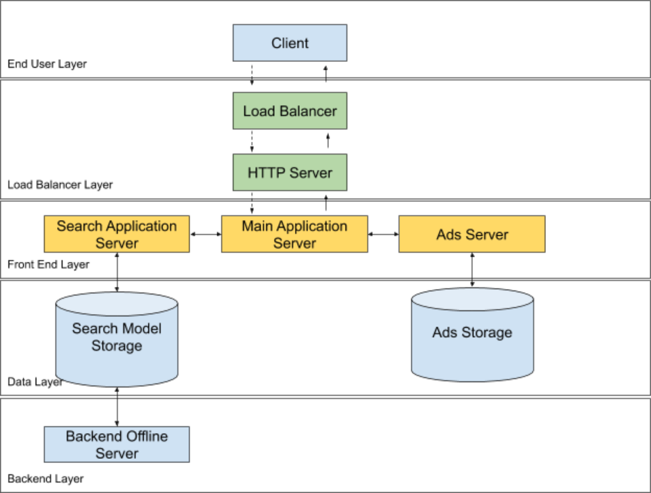

Client:

- 與用戶的交互
  - 内容呈現
  - 功能的體現
  - 用戶輸入(文字, 圖形, 其他形)
- 與後端的信息交流, HTML, XML, JSON
- 數據的本地緩存
- 與其他終端應用的交互, 比如Map, Phone call

HTTP Server

- HTTP Server是用於處理和相應終端的HTTP請求的, 然後根據不同請求的需求, 分發到相應的應用服務器(Application Server)
- Example: https://httpd.apache.org/

Application Server

- An application server is a software framework that provides both facilities to create web applications and a server environment to run them
- 簡單點講: 處理具體的業務邏輯
  - 判斷這個發起者有沒有權利這麽做
  - 根據搜索關鍵詞給出結果(包含所有的基礎信息)
  - 廣告

Storage

- 存儲數據
- 文件系統: 網絡文件系統GFS
- 數據庫: 關係數據庫, 非關係數據庫, SQL

# 2 系統間的通信如何發生

- 域名解析, [DNS](https://www.cloudflare.com/learning/dns/what-is-dns/) (Domain Name System)
- 應用層協議, [HTTP](https://en.wikipedia.org/wiki/Hypertext_Transfer_Protocol), Client與HTTP Server的信息交互
  - HTTP Request操作類型: GET, PUT, POST, DELETE

  ```
  GET /index.html HTTP/1.1
  Host: www.example.com/photo/{ID}
  ```

  - HTTP Response Code: 2xx, 3xx, 4xx, 5xx
- 應用層協議是建立在網絡通信協議之上的
  - TCP (Transmission Control Protocol) 傳輸控制協議
    - 可靠的端到端協議通信協議
    - 三次握手: SYN, SYN ACK, ACK
  - IP (Internet Protocol)
    - 尋址
    - 完成數據包點對點的尋址和傳輸
    - 不保證數據包已被接受

# 3 主要的涉及到性能改進的技術和部分

## 3.1 Load Balancer

A [load balancer](https://www.nginx.com/solutions/load-balancing/) acts as the “traffic cop” sitting in front of your servers and routing client requests across all servers capable of fulfilling those requests in a manner that maximizes speed and capacity utilization and ensures that no one server is overworked, which could degrade performance. If a single server goes down, the load balancer redirects traffic to the remaining online servers. When a new server is added to the server group, the load balancer automatically starts to send requests to it.

- 分流, 分配工作
- 保證服務器不過載
- 當新服務器加入, 可自動分配, 同理, 當服務器被移除, 或者fail, 取消分配請求

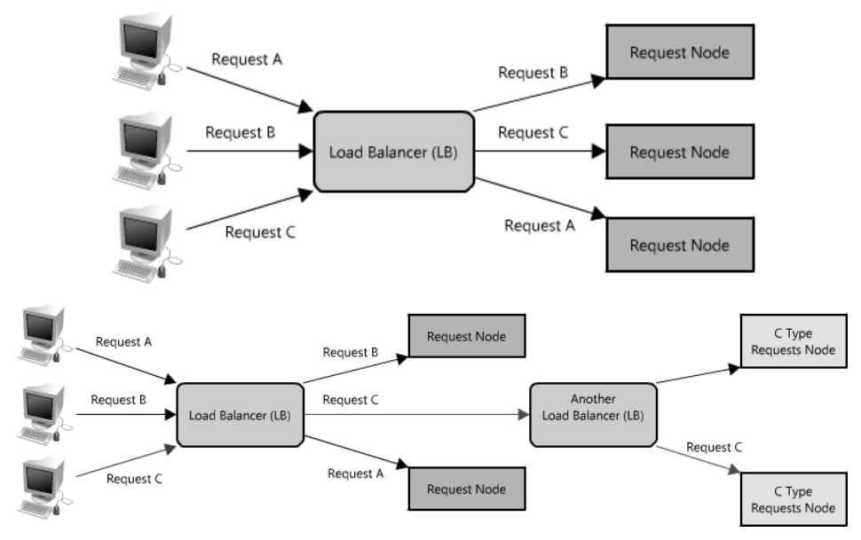

**Load Balancing算法**

- Round Robin: Requests are distributed across the group of servers sequentially.
- IP Hash: The IP address of the client is used to determine which server receives the request.
- Least Connections: A new request is sent to the server with the fewest current connections to clients. The relative computing capacity of each server is factored into determining which one has the least connections.

## 3.2 Caches

Caches take advantage of the locality of reference principle: recently requested data is likely to be requested again. They are used in almost every layer of computing: hardware, operating systems, web browsers, web applications and more. A cache is like short-term memory: it has a limited amount of space, but is typically faster than the original data source and contains the most recently accessed items. Caches can exist at all levels in architecture, but are often found at the level nearest to the front end, where they are implemented to return data quickly without taxing downstream levels.

- 提高數據獲取速度
- 降低數據服務器的負載
- 增加了寫的開銷

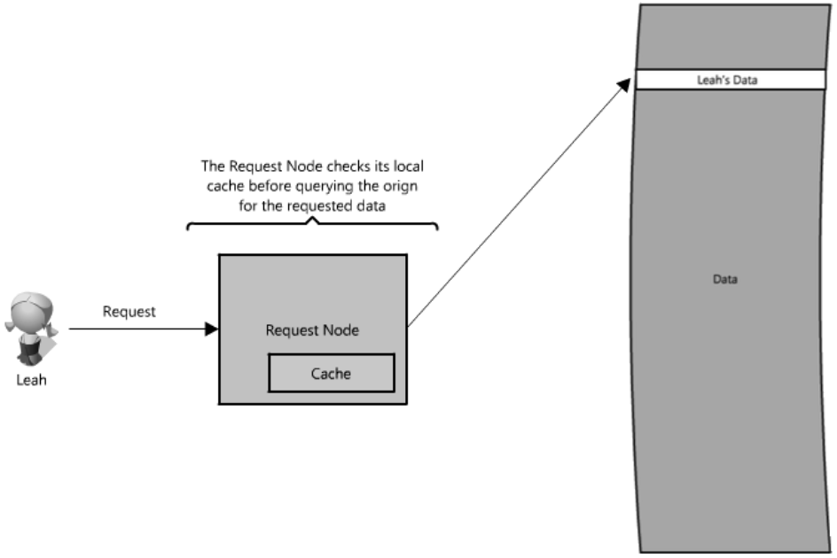

**Local Cache v.s. Global Cache v.s. Distributed Cache**

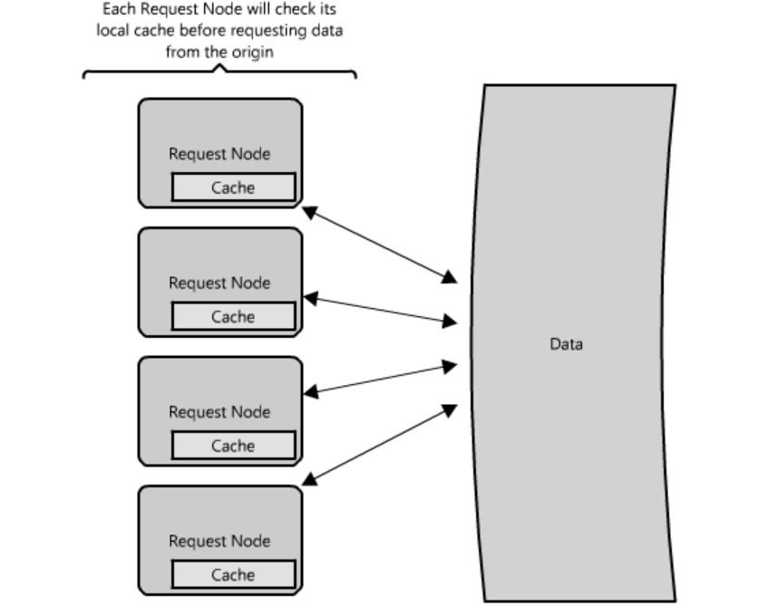

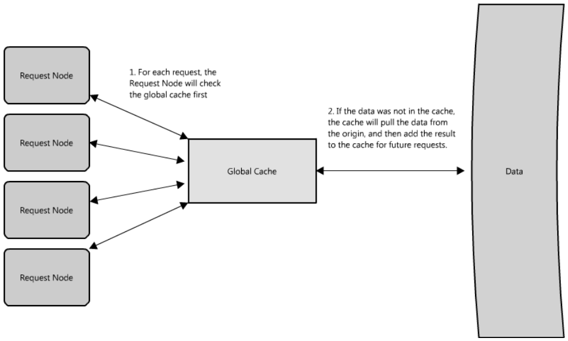

[output not shown]

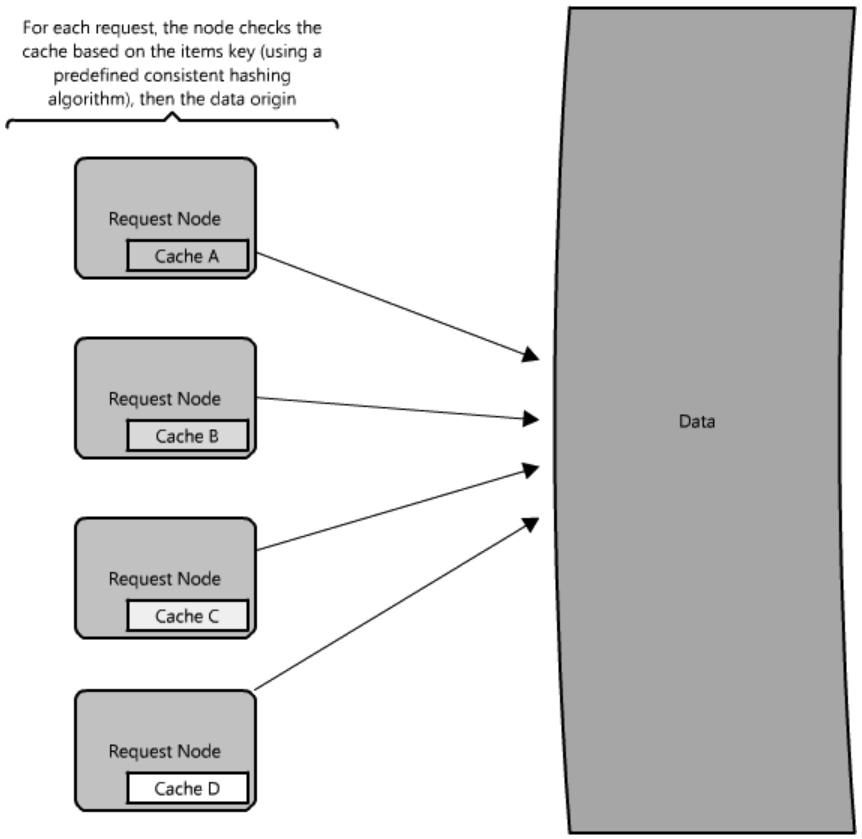

**[LRU](https://www.geeksforgeeks.org/lru-cache-implementation/) Cache Implementation**

## 3.3 Indexing

- 用於更快地訪問數據
- 更多的時候用於數據庫
- 犧牲存儲空間和寫的速度換取更快的讀的速度

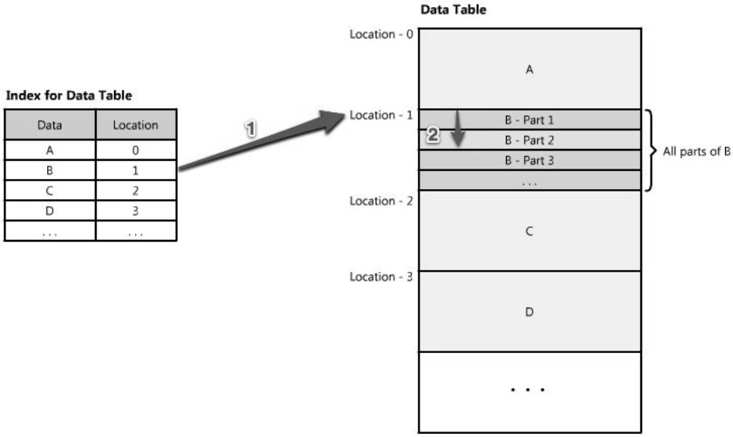

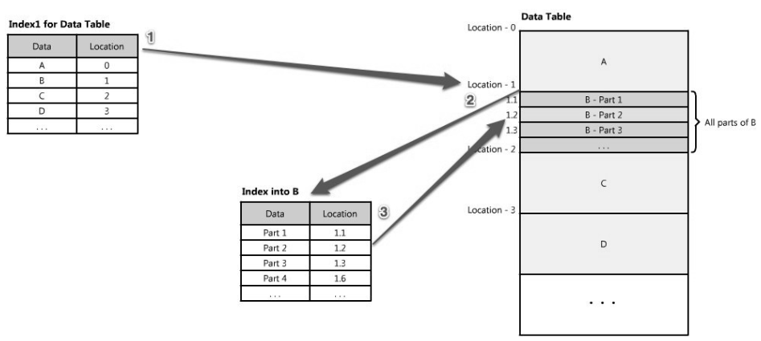

**Bandwidth throttling (rate limiter)**

- 限制服務器最大的響應的QPS (query per second)
- 典型的面試題之一
  - 單位是什麽? 分/秒/小時
  - 怎麽支持spike的情況?
  - Token bucket
    - 記錄上一個request的Timestamp和當前可以接受的request數量
    - 收到新request的時候, 取新request的timestamp
    - 比較當前request的timestamp和之前記錄的那個的差, 相應地給予補給, 比如5000 qps的話, 每單位時間應該給5000個request credit
    - 只要request credit數為正, 則接受, 否則丟棄
    - 設置request credit的上限